# Analyze & Share

kk

2022-05-19

## Analyze and share

```r
## read merged file from summary csv created in last step
getwd()
```

```
## [1] "/Users/kat/Dev/Google-Data-Analytics-R/bike-sharing-capstone"
```

```r
library(readr)
library(tidyverse)
df <- read_csv("output-data/allbikedata-clean_onlyvalidridelength.csv")
```

###**Some descriptive statistics:**

```r
## some descriptive stats
library(skimr)
skim(df)
```

Data summary

| Name | df |
| --- | --- |
| Number of rows | 5757322 |
| Number of columns | 18 |
| _______________________ |  |
| Column type frequency: |  |
| character | 10 |
| numeric | 6 |
| POSIXct | 2 |
| ________________________ |  |
| Group variables | None |

**Variable type: character**

| skim_variable | n_missing | complete_rate | min | max | empty | n_unique | whitespace |
| --- | --- | --- | --- | --- | --- | --- | --- |
| column_label | 0 | 1.00 | 8 | 8 | 0 | 12 | 0 |
| ride_id | 0 | 1.00 | 16 | 16 | 0 | 5757322 | 0 |
| rideable_type | 0 | 1.00 | 11 | 13 | 0 | 3 | 0 |
| start_station_name | 790168 | 0.86 | 3 | 53 | 0 | 865 | 0 |
| start_station_id | 790165 | 0.86 | 3 | 44 | 0 | 856 | 0 |
| end_station_name | 843319 | 0.85 | 10 | 53 | 0 | 864 | 0 |
| end_station_id | 843319 | 0.85 | 3 | 44 | 0 | 856 | 0 |
| member_casual | 0 | 1.00 | 6 | 6 | 0 | 2 | 0 |
| ride_length_period | 0 | 1.00 | 2 | 15 | 0 | 25268 | 0 |
| day_of_week | 0 | 1.00 | 6 | 9 | 0 | 7 | 0 |

**Variable type: numeric**

| skim_variable | n_missing | complete_rate | mean | sd | p0 | p25 | p50 | p75 | p100 | hist |
| --- | --- | --- | --- | --- | --- | --- | --- | --- | --- | --- |
| start_lat | 0 | 1 | 41.90 | 0.05 | 41.64 | 41.88 | 41.90 | 41.93 | 45.64 | ▇▁▁▁▁ |
| start_lng | 0 | 1 | -87.65 | 0.03 | -87.84 | -87.66 | -87.64 | -87.63 | -73.80 | ▇▁▁▁▁ |
| end_lat | 4765 | 1 | 41.90 | 0.05 | 41.39 | 41.88 | 41.90 | 41.93 | 42.17 | ▁▁▁▇▁ |
| end_lng | 4765 | 1 | -87.65 | 0.03 | -88.97 | -87.66 | -87.64 | -87.63 | -87.49 | ▁▁▁▁▇ |
| ride_length | 0 | 1 | 1268.49 | 10323.09 | 0.00 | 387.00 | 691.00 | 1257.00 | 3356649.00 | ▇▁▁▁▁ |
| ride_length_num | 0 | 1 | 1268.49 | 10323.09 | 0.00 | 387.00 | 691.00 | 1257.00 | 3356649.00 | ▇▁▁▁▁ |

**Variable type: POSIXct**

| skim_variable | n_missing | complete_rate | min | max | median | n_unique |
| --- | --- | --- | --- | --- | --- | --- |
| started_at | 0 | 1 | 2021-05-01 00:00:11 | 2022-04-30 23:59:54 | 2021-08-31 17:15:58 | 4820908 |
| ended_at | 0 | 1 | 2021-05-01 00:03:26 | 2022-05-02 00:35:01 | 2021-08-31 17:32:32 | 4815672 |

```r
glimpse(df)
```

```
## Rows: 5,757,322
## Columns: 18
## $ column_label       <chr> "df_05_21", "df_05_21", "df_05_21", "df_05_21", "df…
## $ ride_id            <chr> "C809ED75D6160B2A", "DD59FDCE0ACACAF3", "0AB83CB88C…
## $ rideable_type      <chr> "electric_bike", "electric_bike", "electric_bike", …
## $ started_at         <dttm> 2021-05-30 11:58:15, 2021-05-30 11:29:14, 2021-05-…
## $ ended_at           <dttm> 2021-05-30 12:10:39, 2021-05-30 12:14:09, 2021-05-…
## $ start_station_name <chr> NA, NA, NA, NA, NA, NA, NA, NA, NA, NA, NA, NA, NA,…
## $ start_station_id   <chr> NA, NA, NA, NA, NA, NA, NA, NA, NA, NA, NA, NA, NA,…
## $ end_station_name   <chr> NA, NA, NA, NA, NA, NA, NA, NA, NA, NA, NA, NA, NA,…
## $ end_station_id     <chr> NA, NA, NA, NA, NA, NA, NA, NA, NA, NA, NA, NA, NA,…
## $ start_lat          <dbl> 41.90000, 41.88000, 41.92000, 41.92000, 41.94000, 4…
## $ start_lng          <dbl> -87.63000, -87.62000, -87.70000, -87.70000, -87.690…
## $ end_lat            <dbl> 41.89000, 41.79000, 41.92000, 41.94000, 41.94000, 4…
## $ end_lng            <dbl> -87.61000, -87.58000, -87.70000, -87.69000, -87.700…
## $ member_casual      <chr> "casual", "casual", "casual", "casual", "casual", "…
## $ ride_length        <dbl> 744, 2695, 72, 913, 413, 1416, 883, 1075, 157, 1581…
## $ ride_length_period <chr> "12M 24S", "44M 55S", "1M 12S", "15M 13S", "6M 53S"…
## $ day_of_week        <chr> "Sunday", "Sunday", "Sunday", "Sunday", "Sunday", "…
## $ ride_length_num    <dbl> 744, 2695, 72, 913, 413, 1416, 883, 1075, 157, 1581…
```

- **Average ride length and ride count for members and casual riders:**

```r
# calculate average ride length for members and casual riders
df %>% group_by(member_casual) %>% summarise(mean_length=mean(ride_length_num),
                                             sd_length=sd(ride_length_num))
```

```
## # A tibble: 2 × 3
##   member_casual mean_length sd_length
##   <chr>               <dbl>     <dbl>
## 1 casual              1878.    15423.
## 2 member               789.     1631.
```

```r
print(mean(df$ride_length))
```

```
## [1] 1268.488
```

```r
tapply(df$ride_length, df$member_casual, summary)
```

```
## $casual
##    Min. 1st Qu.  Median    Mean 3rd Qu.    Max.
##       0     530     934    1878    1709 3356649
##
## $member
##    Min. 1st Qu.  Median    Mean 3rd Qu.    Max.
##     0.0   320.0   551.0   788.8   956.0 93595.0
```

```r
colnames(df)
```

```
##  [1] "column_label"       "ride_id"            "rideable_type"
##  [4] "started_at"         "ended_at"           "start_station_name"
##  [7] "start_station_id"   "end_station_name"   "end_station_id"
## [10] "start_lat"          "start_lng"          "end_lat"
## [13] "end_lng"            "member_casual"      "ride_length"
## [16] "ride_length_period" "day_of_week"        "ride_length_num"
```

```r
# count number of casual and member rides
df %>% group_by(member_casual) %>% summarise(count = n())
```

```
## # A tibble: 2 × 2
##   member_casual   count
##   <chr>           <int>
## 1 casual        2536267
## 2 member        3221055
```

- **Bike type and weekdays for members and casual riders:**

```r
# count bike type by members and casual riders
df %>% group_by(member_casual, rideable_type) %>% summarise(count = n())
```

```
## # A tibble: 5 × 3
## # Groups:   member_casual [2]
##   member_casual rideable_type   count
##   <chr>         <chr>           <int>
## 1 casual        classic_bike  1234372
## 2 casual        docked_bike    291382
## 3 casual        electric_bike 1010513
## 4 member        classic_bike  1968298
## 5 member        electric_bike 1252757
```

```r
# count weekdays by members and casual riders
df %>% group_by(member_casual, day_of_week) %>% summarise(count = n())
```

```
## # A tibble: 14 × 3
## # Groups:   member_casual [2]
##    member_casual day_of_week  count
##    <chr>         <chr>        <int>
##  1 casual        Friday      358198
##  2 casual        Monday      289026
##  3 casual        Saturday    558610
##  4 casual        Sunday      476962
##  5 casual        Thursday    298061
##  6 casual        Tuesday     270544
##  7 casual        Wednesday   284866
##  8 member        Friday      453278
##  9 member        Monday      445628
## 10 member        Saturday    442736
## 11 member        Sunday      387960
## 12 member        Thursday    485839
## 13 member        Tuesday     498679
## 14 member        Wednesday   506935
```

## Visualizations

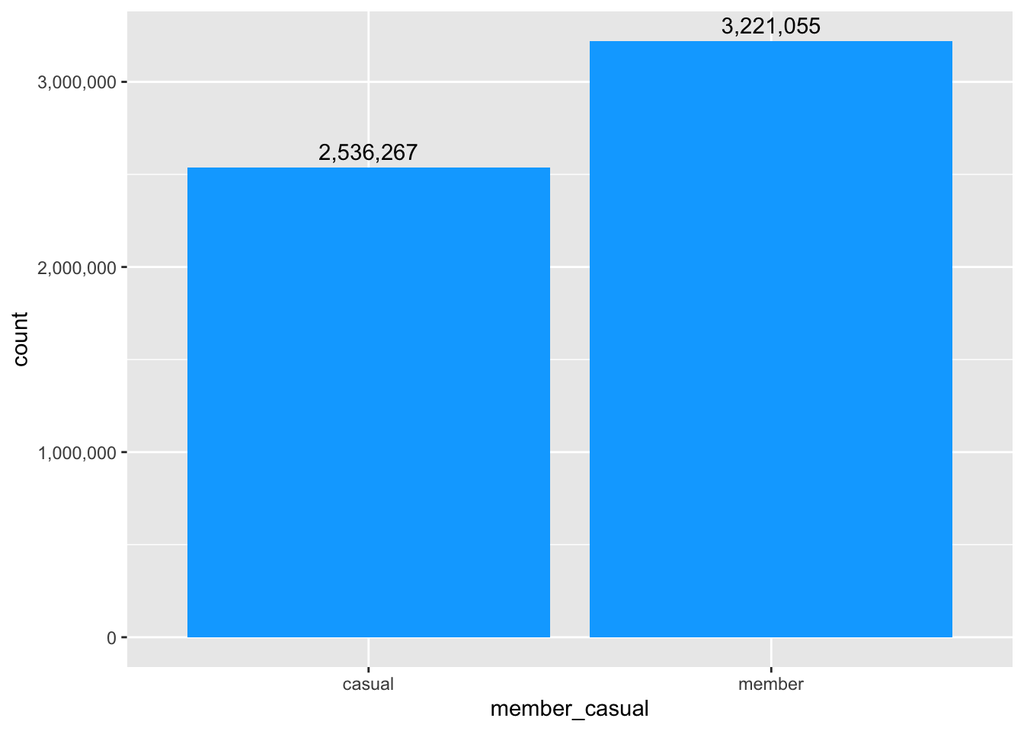

```r
library(ggplot2)
# bar plot of member and causal count
p <- ggplot(data=df, aes(x=member_casual)) +
  geom_bar(fill = "#00abff") +
  geom_text(stat="count", aes(label=scales::comma(..count..)), vjust = -0.5)
## format labels to show actual numbers and not abbreviated
require(scales)
p + scale_y_continuous(labels = comma)
```

```r
# pie charts for bike type by member group
## make dfs with only member or casual type each
df_m <- subset(df, member_casual == "member")
df_c <- subset(df, member_casual == "casual")

## pie chart for members
### make summary df with count as value because the pie chart does not work for me with the actual count
df_m_sum <- df_m %>% group_by(rideable_type) %>% summarise(n = n())
print(df_m_sum)
```

```
## # A tibble: 2 × 2
##   rideable_type       n
##   <chr>           <int>
## 1 classic_bike  1968298
## 2 electric_bike 1252757
```

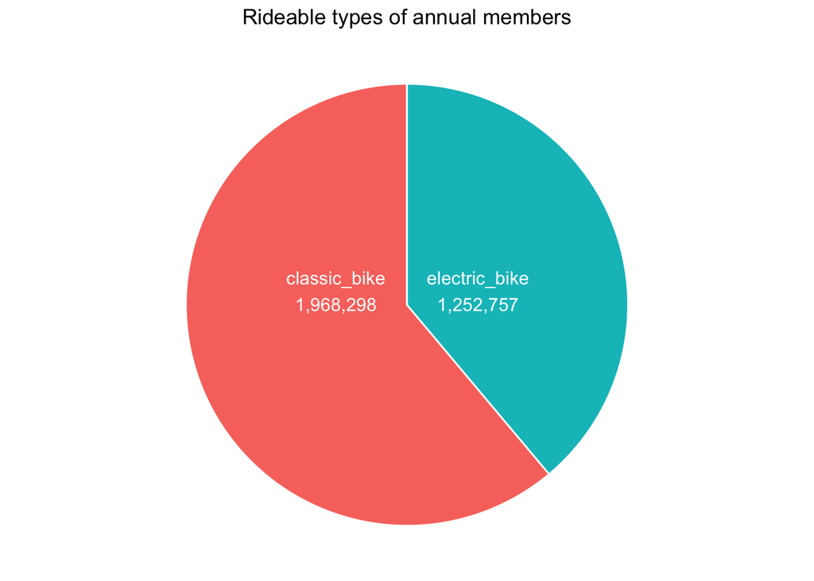

```r
ggplot(df_m_sum, aes(x="",y=n, fill=rideable_type)) +
  geom_bar(stat="identity", width = 1, color="white") +
  coord_polar("y", start=0) +
  theme_void() +
  theme(legend.position = "none", plot.title = element_text(hjust =0.5)) +
  geom_text(aes(y= n, label=scales::comma(n)), color = "white", size=4, vjust=-6) +
  geom_text(aes(y= n, label=rideable_type), color = "white", size=4, vjust=-8) +
  ggtitle("Rideable types of annual members")
```

```r
## pie chart for casual riders
df_c_sum <- df_c %>% group_by(rideable_type) %>% summarise(n = n())
print(df_c_sum)
```

```
## # A tibble: 3 × 2
##   rideable_type       n
##   <chr>           <int>
## 1 classic_bike  1234372
## 2 docked_bike    291382
## 3 electric_bike 1010513
```

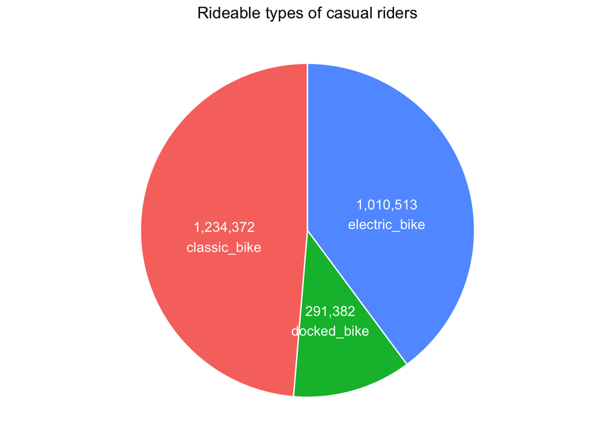

```r
ggplot(df_c_sum, aes(x="",y=n, fill=rideable_type)) +
  geom_bar(stat="identity", width = 1, color="white") +
  coord_polar("y", start=0) +
  theme_void() +
  theme(legend.position = "none", plot.title = element_text(hjust =0.5)) +
  geom_text(aes(y= n, label=scales::comma(n)), position = position_stack(vjust = 0.5), color = "white", size=4) +
  geom_text(aes(y= n, label=rideable_type), position = position_stack(vjust = 0.5), color = "white", size=4, vjust=2.5) +
  ggtitle("Rideable types of casual riders")
```

```r
# histogram for ride lengths
## for members
## does not look like a helpful plot.
#ggplot(df_m, aes(x=ride_length_num)) +
#  geom_histogram(bins = 6) +
#  scale_x_continuous(labels = comma) +
#  scale_y_continuous(labels = comma)
print(mean(df_m$ride_length_num))
```

```
## [1] 788.7578
```

```r
## cut off everything under 10th and over 90th quantile
quantile(df_m$ride_length_num, prob=c(.10,.5,.90))
```

```
##  10%  50%  90%
##  196  551 1555
```

```r
df_m_small <- subset(df_m, (ride_length_num > 196 & ride_length_num < 1555))
mean(df_m_small$ride_length_num)
```

```
## [1] 636.0195
```

```r
median(df_m_small$ride_length_num)
```

```
## [1] 551
```

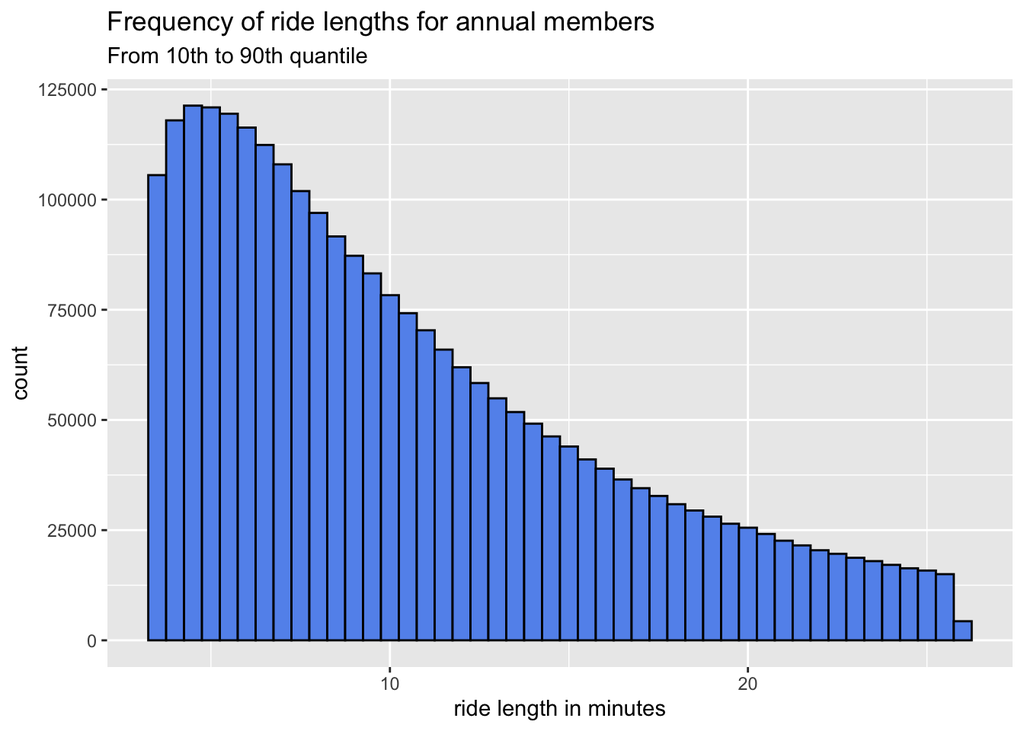

```r
#skim(df_m_small)
df_m_small$ride_length_min <- df_m_small$ride_length_num/60
#skim(df_m_small)

ggplot(df_m_small, aes(ride_length_min)) +
  geom_histogram(binwidth = 0.5, col = "black", fill = "cornflowerblue") +
  labs(title="Frequency of ride lengths for annual members",
       subtitle="From 10th to 90th quantile",
       x="ride length in minutes")
```

```r
## for casual riders
#ggplot(df_c, aes(x=ride_length_num)) +
#  geom_histogram(bins = 6) +
#  scale_x_continuous(labels = comma) +
#  scale_y_continuous(labels = comma)
print(mean(df_c$ride_length_num))
```

```
## [1] 1877.744
```

```r
quantile(df_c$ride_length_num, prob=c(.10,.5,.90))
```

```
##  10%  50%  90%
##  317  934 3217
```

```r
df_c_small <- subset(df_c, (ride_length_num > 317 & ride_length_num < 3217))
mean(df_c_small$ride_length_num)
```

```
## [1] 1127.975
```

```r
median(df_c_small$ride_length_num)
```

```
## [1] 935
```

```r
df_c_small$ride_length_min <- df_c_small$ride_length_num/60
skim(df_c_small)
```

Data summary

| Name | df_c_small |
| --- | --- |
| Number of rows | 2027327 |
| Number of columns | 19 |
| _______________________ |  |
| Column type frequency: |  |
| character | 10 |
| numeric | 7 |
| POSIXct | 2 |
| ________________________ |  |
| Group variables | None |

**Variable type: character**

| skim_variable | n_missing | complete_rate | min | max | empty | n_unique | whitespace |
| --- | --- | --- | --- | --- | --- | --- | --- |
| column_label | 0 | 1.00 | 8 | 8 | 0 | 12 | 0 |
| ride_id | 0 | 1.00 | 16 | 16 | 0 | 2027327 | 0 |
| rideable_type | 0 | 1.00 | 11 | 13 | 0 | 3 | 0 |
| start_station_name | 273767 | 0.86 | 3 | 53 | 0 | 859 | 0 |
| start_station_id | 273765 | 0.86 | 3 | 37 | 0 | 850 | 0 |
| end_station_name | 304764 | 0.85 | 10 | 53 | 0 | 856 | 0 |
| end_station_id | 304764 | 0.85 | 3 | 37 | 0 | 848 | 0 |
| member_casual | 0 | 1.00 | 6 | 6 | 0 | 1 | 0 |
| ride_length_period | 0 | 1.00 | 5 | 7 | 0 | 2899 | 0 |
| day_of_week | 0 | 1.00 | 6 | 9 | 0 | 7 | 0 |

**Variable type: numeric**

| skim_variable | n_missing | complete_rate | mean | sd | p0 | p25 | p50 | p75 | p100 | hist |
| --- | --- | --- | --- | --- | --- | --- | --- | --- | --- | --- |
| start_lat | 0 | 1 | 41.90 | 0.04 | 41.65 | 41.88 | 41.90 | 41.93 | 42.07 | ▁▁▇▇▁ |
| start_lng | 0 | 1 | -87.65 | 0.03 | -87.84 | -87.66 | -87.64 | -87.63 | -87.52 | ▁▁▆▇▁ |
| end_lat | 340 | 1 | 41.90 | 0.04 | 41.57 | 41.88 | 41.90 | 41.93 | 42.12 | ▁▁▇▇▁ |
| end_lng | 340 | 1 | -87.65 | 0.03 | -87.87 | -87.66 | -87.64 | -87.63 | -87.50 | ▁▁▆▇▁ |
| ride_length | 0 | 1 | 1127.98 | 672.58 | 318.00 | 600.00 | 935.00 | 1495.00 | 3216.00 | ▇▅▂▁▁ |
| ride_length_num | 0 | 1 | 1127.98 | 672.58 | 318.00 | 600.00 | 935.00 | 1495.00 | 3216.00 | ▇▅▂▁▁ |
| ride_length_min | 0 | 1 | 18.80 | 11.21 | 5.30 | 10.00 | 15.58 | 24.92 | 53.60 | ▇▅▂▁▁ |

**Variable type: POSIXct**

| skim_variable | n_missing | complete_rate | min | max | median | n_unique |
| --- | --- | --- | --- | --- | --- | --- |
| started_at | 0 | 1 | 2021-05-01 00:00:31 | 2022-04-30 23:59:52 | 2021-08-15 12:18:37 | 1858664 |
| ended_at | 0 | 1 | 2021-05-01 00:09:28 | 2022-05-01 00:33:05 | 2021-08-15 12:39:45 | 1853508 |

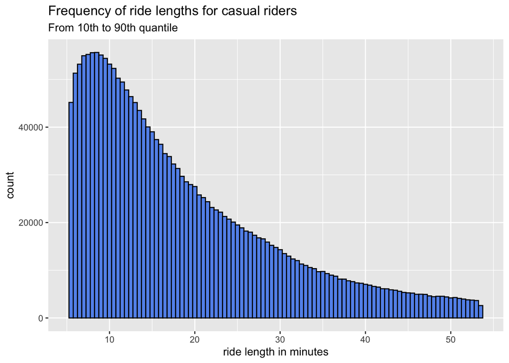

```r
ggplot(df_c_small, aes(ride_length_min)) +
  geom_histogram(binwidth = 0.5, col = "black", fill = "cornflowerblue") +
  labs(title="Frequency of ride lengths for casual riders",
       subtitle="From 10th to 90th quantile",
       x="ride length in minutes")
```

- **Interpretation:** I cut off extreme values on both ends (10% each), so we only see the main distributions here. Annual members seem to make shorter rides than casual riders, most under 10 minutes. Casual riders’ ride length peaks round 10 min, and there are also many rides that go up to 50 min. For annual members, this is rare. Casual riders maybe have a higher barrier to use the bikes, so they might rather use them for rides when it is ‘worth it’.

```r
# bar plot for ride lengths per weekday (ordered), member groups next to each other
## make summary df for ggplot
df_weekday_member <- aggregate(df, by=list(df$day_of_week, df$member_casual), FUN=length)
df_weekday_member <- df_weekday_member %>% select("Group.1", "Group.2", "ride_id")
df_weekday_member <- df_weekday_member %>% rename(weekday = Group.1, member_casual = Group.2, count = ride_id)
#View(df_weekday_member)
df_weekday_member$weekday <- as.factor(df_weekday_member$weekday)
df_weekday_member$weekday <- ordered(df_weekday_member$weekday,
                                     levels = c("Monday", "Tuesday", "Wednesday", "Thursday", "Friday", "Saturday","Sunday"))

glimpse(df_weekday_member)
```

```
## Rows: 14
## Columns: 3
## $ weekday       <ord> Friday, Monday, Saturday, Sunday, Thursday, Tuesday, Wed…
## $ member_casual <chr> "casual", "casual", "casual", "casual", "casual", "casua…
## $ count         <int> 358198, 289026, 558610, 476962, 298061, 270544, 284866, …
```

```r
df_weekday_member$weekday
```

```
##  [1] Friday    Monday    Saturday  Sunday    Thursday  Tuesday   Wednesday
##  [8] Friday    Monday    Saturday  Sunday    Thursday  Tuesday   Wednesday
## 7 Levels: Monday < Tuesday < Wednesday < Thursday < Friday < ... < Sunday
```

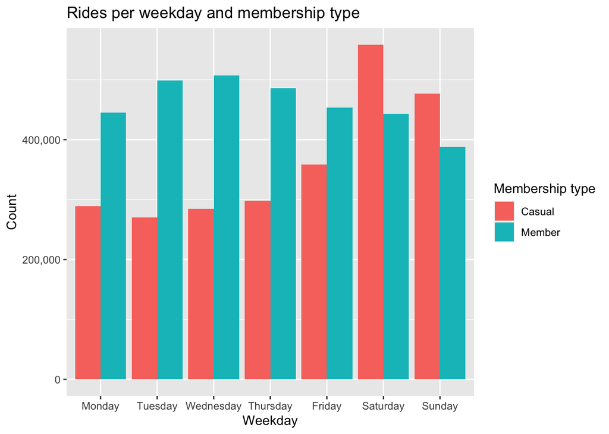

```r
## make bar chart
ggplot(df_weekday_member, aes(x=weekday,y=count,fill=member_casual)) +
  geom_bar(stat="identity", position="dodge") +
  scale_fill_discrete(name="Membership type",
                      breaks=c("casual","member"),
                      labels=c("Casual", "Member")) +
  xlab("Weekday") + ylab("Count") +
  scale_y_continuous(labels = comma) +
  labs(title="Rides per weekday and membership type")
```

```r
# casual riders tend to ride more on weekends, members more during weekdays
```

- **Interpretation:** Casual riders tend to ride more during weekends, annual members more during weekdays. This could mean that casual riders use the bikes in their freetime, annual members for work.

### Ideas to improve data / analysis

- There is no member id in the data (probably privacy reasons), but so we don’t know how many rides members and casual riders make. If the company could provide this data safely, it could give more interesting insights.
- I could have spent way more time reporting the numbers, most of my interpretations rely only on the visualizations. This was a time-issue, and I might come back to this analysis later to give a more complete analysis and interpretation.